# Typeracer and Typing Improvement

Turbo Typing Through Typeracer

### Group Members

- Stanley Tzeng
- Yi Hsuan Chang Chien
- Steven Stehl
- Geoffrey Xue
- Vishnu Anand

## Introduction

Today, we spend a significant portion of time on our computers, typing as our main method of input. As a collective, we were interested in exploring patterns of typing and typing habits. In grade school, we all used to learn how to type on different typing software tools, with the overall goal of getting “better” at typing. One of the more popular typing software tools is typeracer.

**Typeracer[^1]** is an online typing software where you race against other typists on “text tracks”. For every game, a random quote/paragraph is selected for the race, and racers are challenged to type the excerpt as fast as possible. Over time, racers build up a history of typing on hundreds or thousands of texts, accumulating data and a log of typing records.

### Focus

Our main question of interest is centered around this claim of getting “better” at typing through use of typing software like typeracer. **In specific, *causationally*, how much do the number of races on typeracer increase typing speed for a dedicated typeracer typist? We hypothesize that generally, dedicated typists will experience significant improvement over the span of their races.**

## Background

### How do Typeracer Races Work? How do they correlate to Real World Typing?

In typeracer, racers are prompted with a text track, or a random quote or phrase, which they are intended to type as quickly and as accurately as possible in order to out-score opposing racers. Each of these text tracks has varying word lengths, as well as varying amounts of capitalization and punctuation use. Text tracks are designed to represent real world typing scenarios as accurately as possible in order to best improve one’s typing abilities beyond the scope of typeracer, itself.

### Note: Causational Relationship

Typing is mostly a practiced skill; improvement really only comes with more practice. Since our sample is populated with incredibly dedicated power users who spend substantial amounts of time on the site, it’s reasonable to assume that a good amount of their typing improvement is a result of their typeracer practice/results. Therefore, we can conclude that there is somewhat of a causational relationship between a user’s number of races and a user’s typing improvement.

### Data and Data Wrangling

As stated prevously every time a racer races, typeracer will log that race, along with some statistics, and tie that with your account. This provides a method for racers to review their performance over time, but also generates an effective dataset for analysis. Our hypothesis will primarily use lists of these races and the associated data logged.

Despite the fact that typeracer maintains this list of races for each player, there is no publicly available list of players. To find metadata about users (specifically their user ids), we are utilizing a third-party website, **typeracerdata[^2]**, that aggregates and logs racer ids and some associated statistics for viewing. Players can manually enter themselves into typeracerdata and then can query themselves for updates.

To collect and unify our data, we will first filter names of typists from typeracerdata based on a variety of variables (race, texts, etc.), and then individually query each name for their races from typeracer. This data will then be our main data set for this analysis.

#### Part 1: General Sampling for Typist Metadata

As stated above, we have to use typeracerdata to first get the metadata for users. Conveniently, typeracerdata allows us to filter racers as well. Typeracerdata has an endpoint where you can filter and sort by a few key identifiers:

Endpoint: `http://typeracerdata.com/leaders?`

- min_races - filter minimum number of races allowed
- min_texts - filter minimum number of unique texts raced
- rank_start - ranking start
- rank_end - ranking end
  - For example, rank_start = 0 and rank_end = 50 will pull the first 50 racers
- sort - a sorting category

In our analysis, we filtered typists based on these their total races and total texts. Below is an example query used for querying a list of typists based on some parameters:

Example: `https://typeracerdata.com/leaders?min_races=2500&min_texts=500&sort=races&rank_start=1&rank_end=100000`

This will pull all users with more than 500 unique texts raced and more than 2500 races. We can then scrape the html table and specifically filter for a limit for races.

Note: If you wish to reproduce this, you have to keep in mind that the `racer` column in typeracerdata echos not only their typist id, but also nickname. If the nickname is too long, their typist is cut off. To obtain their actual id, you can instead grab the link attached to every racer column cell, which contains a link to their profile. Using regex, you can parse and merge their data with their true id.

After obtaining a tibble , we perform simple random sampling within the filtered group to get exactly 100 typists. We’ll then take these 100 typists and store them individually in a csv with the following columns:

- *name* - id of typist, or their true name (this distinction is important because every typist also as a nickname only for display)
- *races* - total number of races typed
- *texts* - total number of unique texts typed

#### Part 2: Obtaining Actual Data from Metadata

After obtaining this list of 100 racers, we then query a typeracer endpoint for each of their race logs by ID:

Endpoint: `https://data.typeracer.com/games?`

- playerId - the id of the racer, preceded by `tr:`
- n - the total number of races to be pulled

Below is an example query for getting a user’s data:

Example: `https://data.typeracer.com/games?playerId=tr:ulmaa&n=2500`

This will pull the latest 2500 races from a player with the id “ulmaa” in a json list, with each object containing the below format:

- *wpm* - Words per minute on text (related to typing speed)
- *ac* - Accuracy on text (related to accuracy)
- *t* - timestamp of race (related to duration of racing)
- *tid* - text id
- *gn* - game number (Standardizing game numbers)
- *pts* - points = words/sec * words in text (related to length of text)

We queried each player by their id and total races, grabbing all of their races. Finally, we combined all of these races into an aggregate csv. Each row in this csv represents a race, with each race containing:

- *name* - id of typist
- *wpm* - words per minute
- *accuracy* - accuracy on text
- *time* - timestamp of race
- *game_num* - game number
- *points* - points of race

This csv is the data we use for our analysis.

### Potential Unusual Factors and Mitigation

One potential unusual factor in our data is a phenomenon of premium repeat racing. For a certain amount a month, typeracer will grant you premium status. Alongside some minor cosmetic changes, premium status allows you to log 5 races on any quote you desire per day throughout practice. This means that some premium users may specifically replay easier texts to score an inflatedly high wpm average. Usually, these premium accounts will either have very few unique texts raced or be an extremely decorated profile with tens of thousands of races. These texts would deviate from their standard texts raced as outliers. In an effort to reduce this problem, we can set a minimum bar of total text raced and an upper limit (3000) for the definition of a dedicated racer so that these accounts are filtered out.

### Study Brief

After wrangling all our data, we can begin to study our dataset. We’ll start by validating our experimental assumptions to make sure that we can apply proper statistical models/procedures to our dataset. Then, we want to perform a hypothesis test to see if there exists a relationship between a user’s number of races and their typing improvement. Finally, we’ll analyze and draw conclusions from our results.

## Analysis

### General Assumptions

There are several general assumptions we make of the data throughout our paper. Some of the following are listed below:

- Typing wpm progress is linear to the times one has played
- The typing wpm variance does not increase as the race number or wpm increases, stays constant throughout the graph
  - In other words, the residual standard deviation is constant throughout all races
- We assume a racer’s progress is proportional to their starting wpm, regardless of their actual starting wpm

These assumptions will be further explored in the data exploration section below.

### Data Exploration and Mutation

#### Heteroscedasticity

Since we’re doing a regression model for each typist, we must assume that, across the line, the mean of the residuals is 0 and the variation is constant.

First, we provide an example of a typist’s improvement in general. Here, we grab a specific user from our data to graph their improvement with a sample regression line.

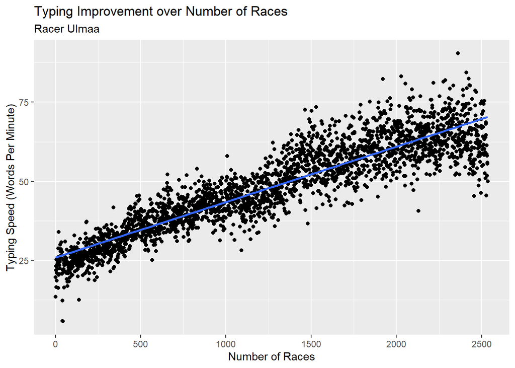

From observing this graph, we see that there is a bit of heteroscedasticity. As the the typist increases in their number of races, it seems like there is more variation in their words per minute. Therefore, the variation over the regression line is not constant. For the sake of this analysis, we’ll just assume this to be not the case.

Next, we look at the residual plots for this sample racer after fitting a linear regression model. Here, we calculate the m and b described below in our approach, but we subtract from the true wpm, finding the residual of the graph.

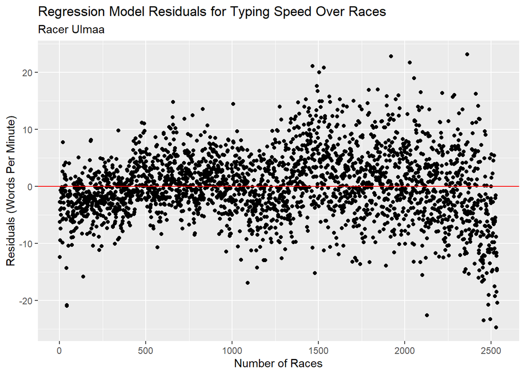

Here, the graph highlights that our second assumption seems to hold true - the mean across the graph is about 0. The graph doesn’t appear to show significant skewedness throughout the entirely of the curve. Again, heteroscedasticity is present in the graph.

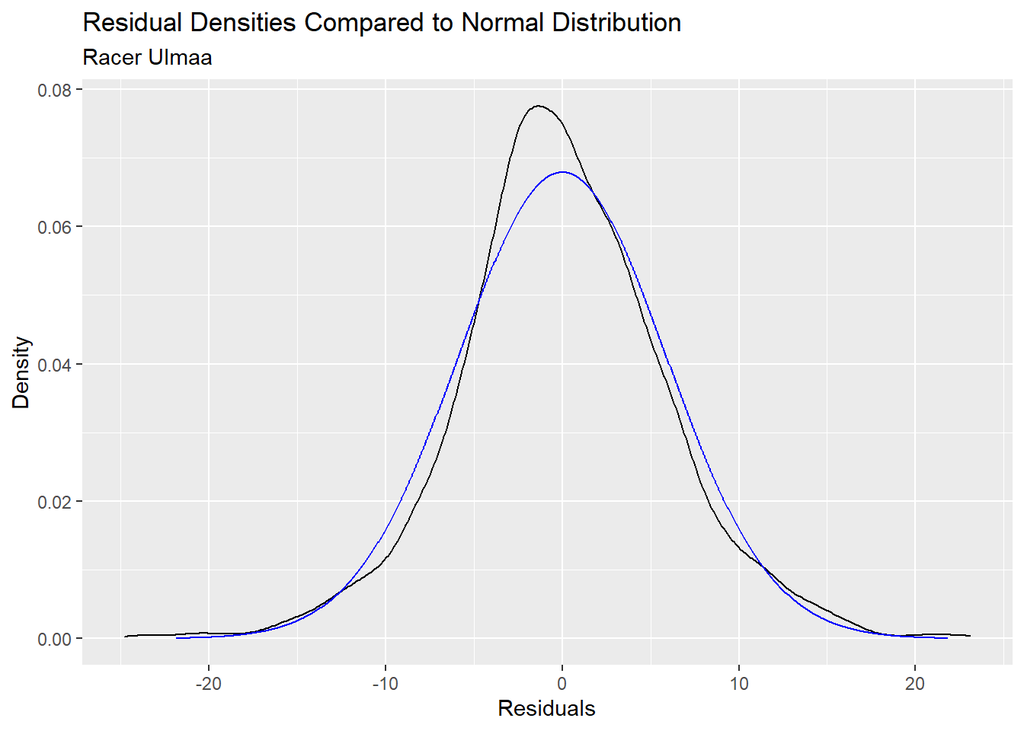

From this graph, we can see the residual density distribution seems relatively close to a normal distribution; the normal distribution is a reasonable approximation of the distribution of variation of points around the regression line.

Since there is only slight heteroscedastcity and the methods to factor this impact is outside of the scope of this course, we will assume that these conditions for linear regression hold.

### Approach

Using our data set, we draw a regression line relative to wpm and game_number and find the slope and intercept for each racer. Afterwards, we then calculate the estimate improvement of a racer relative to their starting wpm. To calculate their estimated wpm, we can use

$$wpm = game\_num * slope + intercept \\
f(x) = x * m + b$$

To calculate their improvement relative to their estimated wpm, we can find the difference between their first estimated wpm and last race estimated wpm and then divide that by their first estimated wpm:

$$imp = \dfrac{f(last\_game\_num) - f(first\_game\_num)}{f(first\_game\_num)} \\
= \dfrac{f(n) - f(0)}{f(0)} \\
= \dfrac{n * m + b - b}{b} \\
= \dfrac{n * m}{b}$$

Below is a preliminary list of racers along with their total races typed and their improvement proportional to their starting estimated wpm:

| name | n | imp |
| --- | --- | --- |
| 0932275045 | 2785 | 0.3308743 |
| 2eazzy | 2749 | 0.0365960 |
| abetterplace | 2848 | 0.7528710 |
| abhib22 | 2762 | 0.3084854 |
| adc4392 | 2726 | 0.0590149 |
| akellomukasa | 2535 | 0.1668499 |

### General Summaries

Here are some general statistics about our dataset and the above calculations.

| worst_race_wpm | average_race_wpm | best_race_wpm | worst_race_acc | average_race_acc | best_race_acc | average_racers |
| --- | --- | --- | --- | --- | --- | --- |
| 5.67 | 75.70846 | 274.99 | 0.57 | 0.9566814 | 1 | 4.302911 |

The race_wpm statistic represents any given users’ wpm for any given race. Similarly, race_acc is any given users’ accuracy for any given race. The worst (min), average (mean), and best (max) summary statistics are calculated here to give us a general understanding of the range of all Typeracer users’ wpm and accuracy.

| total | min_imp | mean_imp | max_imp |
| --- | --- | --- | --- |
| 100 | -0.1004762 | 0.387853 | 1.714213 |

Total represents the total number of typists. min/mean/max imp represents the range of the relative improvement for each user (a statistic which we described earlier).

#### Distribution of WPM Improvement

This graph provides key evidence for the question of whether typing has improved over the span of each individual’s races, as it shows the percent improvement in their estimated starting wpm and ending wpm in a linear regression. The violin plot combined with the jittered points shows most improvement falling between 0 and 50% at around 20%. The distribution is right skewed relative to improvement, as there are some in the distribution that show significantly more relative wpm improvement at around 50 - 150%.

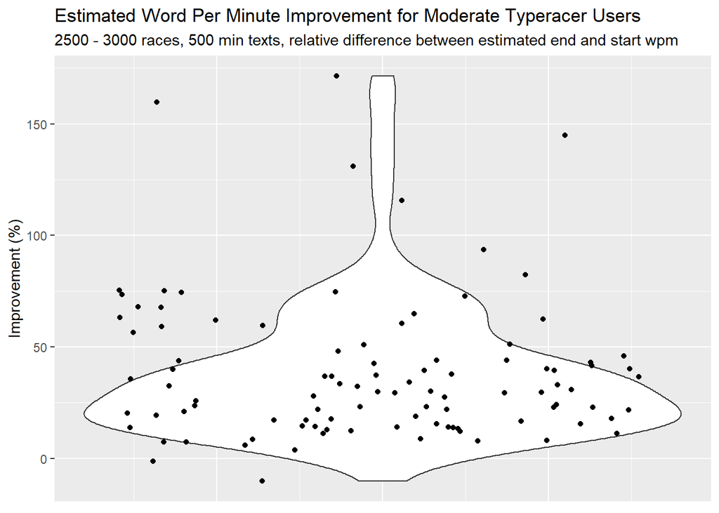

### Hypothesis Test and Confidence Interval

We will use a **Student’s T Test** to evaluate the average typing improvements over the span of races for typists.

#### Population and Sample

- The population is typists on typeracer who have between 2500-3000 races and at least 500 texts logged.
- The sample is the 100 typists randomly sampled out of the ~1.6k

#### Parameters

- We are looking at the improvement of a typist relative to their estimated wpm, so:
- $\mu$ is the mean improvement
- $\sigma$ is the standard deviation of this improvement

#### Statistical Model

- improvements for each typist are $x_1,\dots,x_n$ for $n = 100$
- Model these times as a random sample from the larger population
  - $F$ is the unspeified distribution
  - $\mu$ be the mean
  - $\sigma$ be the standard deviation

#### Hypothesis

$$H_0: \mu = 0 \\
H_a: \mu > 0$$

#### Test Statistic

- Standardize the sample mean and compare it to a known distribution
  $$T = \frac{\bar{X} - \mu}{s / \sqrt{n}} \sim t(n-1)$$
- where $t(n-1)$ is a $t$ distribution with $n-1$ degrees of freedom

### Results

The test statistic is 11.9257. The p-value is 3.6990967^{-21}, which is effectively 0.

The confidence interval values span from 0.3339 upwards.

## Discussion

### Interpreting Results

There is overwhelming evidence that the mean improvement, by proportion, for a typist relative to their starting estimated wpm over races is greater than 0 (p is 0, < 0.05), one-sided t-test, df=99).

In other words, there is overwhelming evidence that a typist, based on their starting estimated wpm, experienced improvement over races.

We are 95% confident that the true mean improvement of dedicated typeracer users, relative to their starting wpm as a proportion, is greater than 0.3339.

Overall, it seems like all our findings point towards the fact that dedicated typeracer users experience some level of improvement through the use of typeracer. This improvement is quite variable and depends on the users’ starting words per minute, but there is a good amount of evidence suggesting that typeracer does in-fact improve dedicated users’ wpm.

### Future Options for Analysis

While this study has provided us with evidence showing the positive correlation of typing improvement over a certain span of races, it also provides the opportunity for future analysis of typeracer efficacy in different aspects. For example, one could explore the ways in which overall time spent on typeracer correlates to typing speed improvement. In exploring this analysis, one would be able to focus more on the overall typing time and and focus less on the typing race density. In addition, one could perform an analysis on the ways in which text length impacts typing. It is commonly held that typing for a longer period of time will in-turn make a typist type “worse,” this analysis would provide the opportunity to see if this is true within the context of a typing software, such as typeracer. This data set provides the opportunity to explore a multitude of relationships between different typing factors.

This analysis only evaluates the average wpm improvement for dedicated players. However, we do not analyze the range of improvement for individual players. This could be an interesting avenue of exploration with this dataset in the future too.

Our dataset includes only a very specific set of players (2.5k - 3k races, >500). Future analysis can be done for a less dedicated set of players falling closer to the median number of races.

### Potential Shortcomings

There are several potential shortcomings with our analysis. We’ve highlighted some of them below:

- We don’t have definite control over factoring the effect of time between races in our analysis. We have not calculated or evaluated the impact of average time intervals between races in our analysis
- Current power users may improve at a greater rate than normal users, as users who see more improvement are more motivated to stick with typeracer and race more races. This may artificially inflate the average improvement slope.
- Typeracer as a software has evolved over time from 2008 to 2021. While data spans back to 2010, we have not considerably evaluated text variety and text difficulty differences between times, which may skew our data
- As we mentioned earlier, there was some amount of heteroscedasticity that we could visibly observe present in our data. This could invalidate our statistical analysis methods since it directly contradicts some of our assumptions.
- In our analysis of the Typeracer data, we did not factor in the racer’s ages or the potential for racers to have disabilities affecting their typing improvement. While we were not provided with data relative to these elements, they can certainly have an impact on the ability for typeracer users to improve their typing abilities.

## References

[^1]: typeracer.com
[^2]: [typeracerdata.com](https://typeracerdata.com/leaders)